# Identify-intersections

Satya Golla and Steve Simon

11/17/2021

This program will read in census shapefiles for counties, public use microdata areas, census tracts, census block groups, census blocks, and zip code tabulation areas. Then it will compare them to the shapefiles for community districts and neighborhoods.

For each community district and for each neighborhood, this program will find which counties, census tracts, etc. intersect. In some cases a single census shapefile will contain the entire community district or neighborhood. In addition, the program will compute the area of each census shapefile and what percentage of that area lies inside or outside the community district or neighborhood.

The program will then attach total population and total housing units to these census shapefiles using the 2020 Census redistricting files.

Finally, this program will read data from the American Community Survey, download information from the Census website, and re-allocate values to individual community districts and neighborhoods.

### General information

The starting point for downloading most Census shapefiles is [here](https://www.census.gov/geographies/mapping-files/time-series/geo/tiger-line-file.html). The ftp site is a bit more difficult to navigate, but leads you directly to the files that you want.

It helps to know the FIPS (Federal Information Processing System) codes for Kansas (20) and Missouri (29).

### US counties shapefiles

There is a [single file](https://www2.census.gov/geo/tiger/TIGER2021/COUNTY/tl_2021_us_county.zip) of counties for all of the United States. Use the st_read function from the [sf package](https://r-spatial.github.io/sf/) to read in the data. You may need to convert the coordinate reference system. That uses the st_crs function, also of the sf package. Counties are uniquely identified by a two digit state FIPS code and a three digit county FIPS code. These are combined into a five digit code, GEOID.

The important counties for this program are

Cass County, MO (29037) Clay County, MO (29047) Jackson County, MO (29095) Johnson County, KS (20091) Leavenworth County, KS (20103) Miami County, KS (20121) Wyandotte County, KS (20209)

```r
library(sf)
library(tidyverse)
path_name <- "../data"
file_name <- "tl_2021_us_county.shp"
path_name                              %>%
  paste(file_name, sep="/")            %>%
  st_read(stringsAsFactors=FALSE)      -> all_counties
head(all_counties)
```

```
## Simple feature collection with 6 features and 17 fields
## Geometry type: MULTIPOLYGON
## Dimension:     XY
## Bounding box:  xmin: -123.7283 ymin: 18.11774 xmax: -65.81565 ymax: 46.38562
## Geodetic CRS:  NAD83
##   STATEFP COUNTYFP COUNTYNS GEOID        NAME              NAMELSAD LSAD
## 1      31      039 00835841 31039      Cuming         Cuming County   06
## 2      53      069 01513275 53069   Wahkiakum      Wahkiakum County   06
## 3      35      011 00933054 35011     De Baca        De Baca County   06
## 4      31      109 00835876 31109   Lancaster      Lancaster County   06
## 5      31      129 00835886 31129    Nuckolls       Nuckolls County   06
## 6      72      085 01804523 72085 Las Piedras Las Piedras Municipio   13
##   CLASSFP MTFCC CSAFP CBSAFP METDIVFP FUNCSTAT      ALAND   AWATER    INTPTLAT
## 1      H1 G4020  <NA>   <NA>     <NA>        A 1477645345 10690204 +41.9158651
## 2      H1 G4020  <NA>   <NA>     <NA>        A  680976231 61568965 +46.2946377
## 3      H1 G4020  <NA>   <NA>     <NA>        A 6016818946 29090018 +34.3592729
## 4      H1 G4020   339  30700     <NA>        A 2169272970 22847034 +40.7835474
## 5      H1 G4020  <NA>   <NA>     <NA>        A 1489645185  1718484 +40.1764918
## 6      H1 G4020   490  41980     <NA>        A   87748418    32509 +18.1871483
##       INTPTLON                       geometry
## 1 -096.7885168 MULTIPOLYGON (((-96.55515 4...
## 2 -123.4244583 MULTIPOLYGON (((-123.4908 4...
## 3 -104.3686961 MULTIPOLYGON (((-104.3837 3...
## 4 -096.6886584 MULTIPOLYGON (((-96.6814 41...
## 5 -098.0468422 MULTIPOLYGON (((-98.04802 4...
## 6 -065.8711890 MULTIPOLYGON (((-65.85703 1...
```

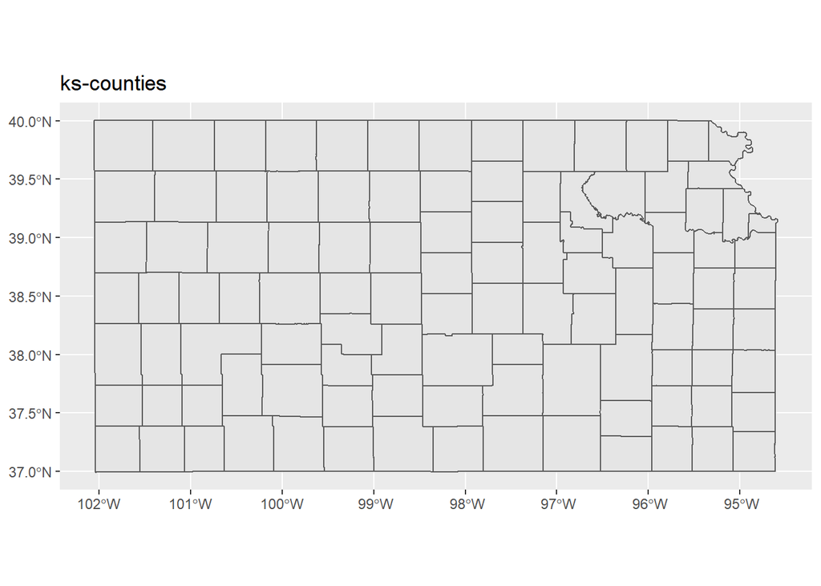

```r
all_counties                           %>%
   filter(STATEFP==20)                    %>%
   ggplot()                              +
      geom_sf(aes())                    +
      ggtitle("ks-counties")
```

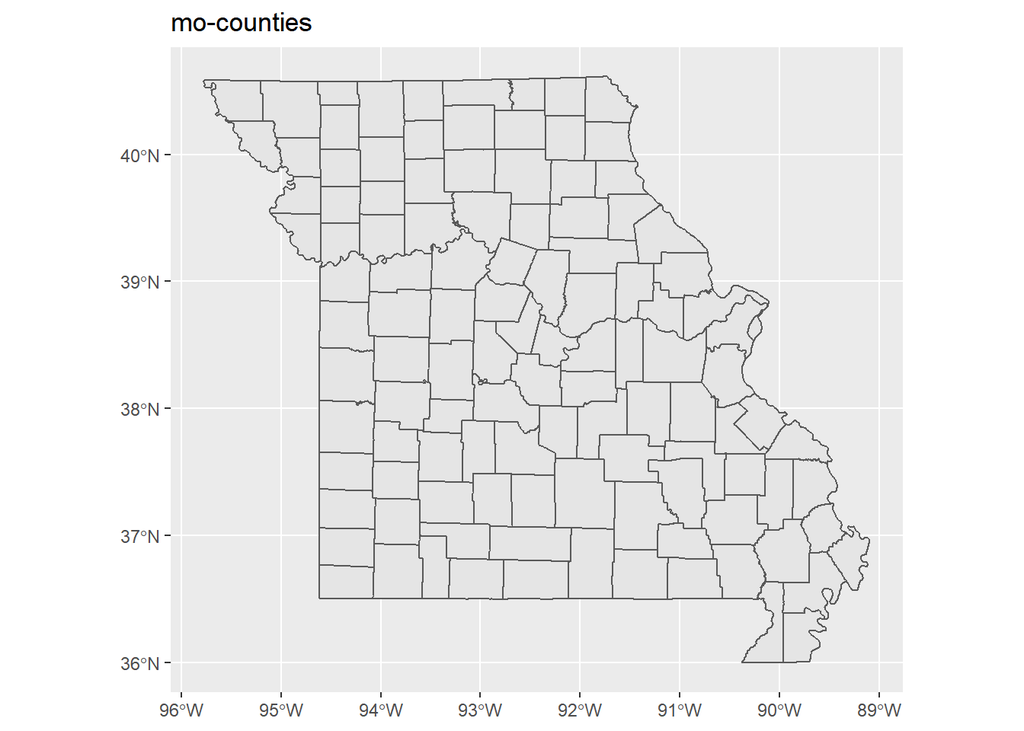

```r
all_counties                           %>%
   filter(STATEFP==29)                    %>%
   ggplot()                              +
      geom_sf(aes())                    +
      ggtitle("mo-counties")
```

### Public Use Microdata Areas (PUMA)

A PUMA is a region within a state that contains no less than 100,000 people. There are files for PUMAs for [Kansas](https://www2.census.gov/geo/tiger/TIGER2021/PUMA/tl_2021_20_puma10.zip) and [Missouri](https://www2.census.gov/geo/tiger/TIGER2021/PUMA/tl_2021_29_puma10.zip). The various functions described in the US counties shapefiles section will be used here.

```r
path_name <- "../data"
file_name <- "tl_2021_20_puma10.shp"
path_name                              %>%
  paste(file_name, sep="/")            %>%
  st_read(stringsAsFactors=FALSE)      -> all_puma_ks
head(all_puma_ks)
```

```
## Simple feature collection with 6 features and 10 fields
## Geometry type: POLYGON
## Dimension:     XY
## Bounding box:  xmin: -98.48065 ymin: 37.62876 xmax: -94.705 ymax: 39.10534
## Geodetic CRS:  NAD83
##   STATEFP10 PUMACE10 GEOID10
## 1        20    00603 2000603
## 2        20    01301 2001301
## 3        20    01000 2001000
## 4        20    00801 2000801
## 5        20    00700 2000700
## 6        20    00601 2000601
##                                                                         NAMELSAD10
## 1  Johnson County (Southwest)--Olathe, Gardner, Spring Hill & Edgerton Cities PUMA
## 2 Sedgwick (Northwest) & Harvey Counties--Wichita (Northwest) & Newton Cities PUMA
```

[output cut: 18 more lines]

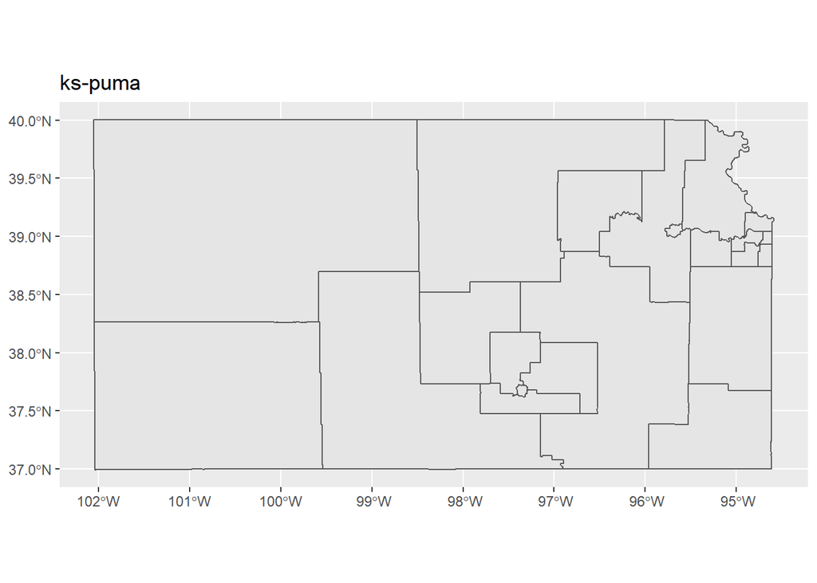

```r
all_puma_ks                           %>%
     ggplot()                              +
      geom_sf(aes())                    +
      ggtitle("ks-puma")
```

variable in the file

- Variables:
  - “STATEFP10”
  - “PUMACE10”
  - “GEOID10”
  - “NAMELSAD10”
  - “MTFCC10”
  - “FUNCSTAT10”
  - “ALAND10”
  - “AWATER10”
  - “INTPTLAT10”
  - “INTPTLON10”
  - “geometry”

```r
path_name <- "../data"
file_name <- "tl_2021_29_puma10.shp"
path_name                              %>%
  paste(file_name, sep="/")            %>%
  st_read(stringsAsFactors=FALSE)      -> all_puma_mo
head(all_puma_mo)
```

```
## Simple feature collection with 6 features and 10 fields
## Geometry type: POLYGON
## Dimension:     XY
## Bounding box:  xmin: -94.60243 ymin: 36.80918 xmax: -90.26498 ymax: 39.78906
## Geodetic CRS:  NAD83
##   STATEFP10 PUMACE10 GEOID10
## 1        29    02601 2902601
## 2        29    01804 2901804
## 3        29    01803 2901803
## 4        29    00800 2900800
## 5        29    01004 2901004
## 6        29    01002 2901002
##                                                             NAMELSAD10 MTFCC10
## 1 Christian, Greene (Outside Springfield City) & Webster Counties PUMA   G6120
## 2                                         St. Louis County (West) PUMA   G6120
```

[output cut: 18 more lines]

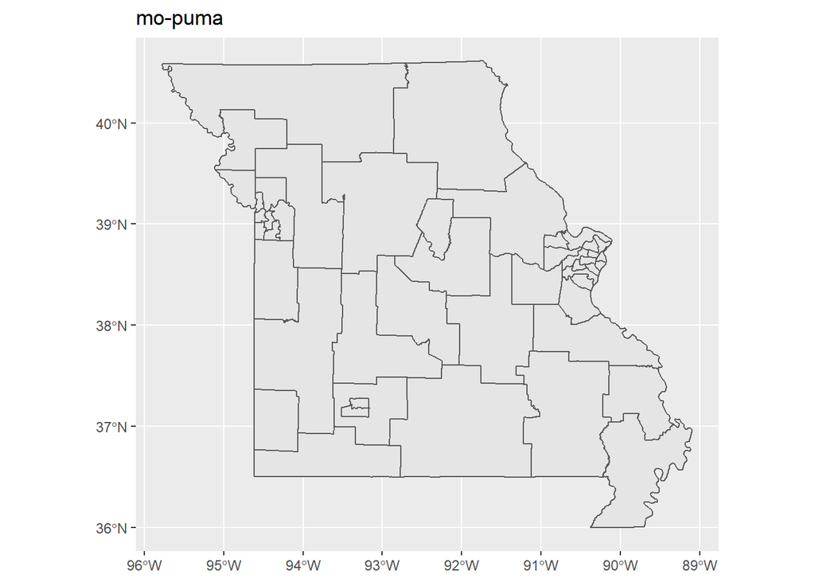

```r
all_puma_mo                           %>%
     ggplot()                              +
      geom_sf(aes())                    +
      ggtitle("mo-puma")
```

variable in the file

- Variables:
  - “STATEFP10”
  - “PUMACE10”
  - “GEOID10”
  - “NAMELSAD10”
  - “MTFCC10”
  - “FUNCSTAT10”
  - “ALAND10”
  - “AWATER10”
  - “INTPTLAT10”
  - “INTPTLON10”
  - “geometry”

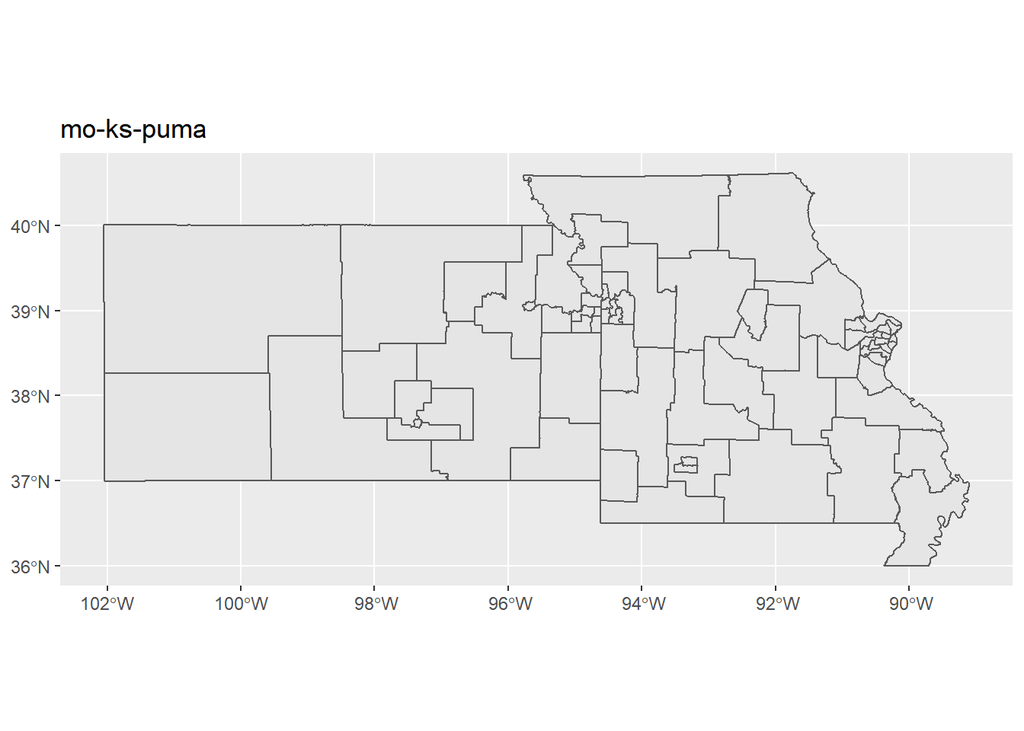

```r
all_puma_ks                %>%
  bind_rows(all_puma_mo)                %>%
 ggplot()                               +
      geom_sf(aes())                    +
      ggtitle("mo-ks-puma")
```

### Census tracts

A Census tract is a region usually within a single county that contains roughly 4,000 people. There are files for census tracts for [Kansas](https://www2.census.gov/geo/tiger/TIGER2021/TRACT/tl_2021_20_tract.zip) and [Missouri](https://www2.census.gov/geo/tiger/TIGER2021/TRACT/tl_2021_29_tract.zip). The various functions described in the US counties shapefiles section will be used here.

```r
path_name <- "../data"
file_name <- "tl_2021_20_tract.shp"
path_name                              %>%
  paste(file_name, sep="/")            %>%
  st_read(stringsAsFactors=FALSE)      -> all_tract_ks
head(all_tract_ks)
```

```
## Simple feature collection with 6 features and 12 fields
## Geometry type: POLYGON
## Dimension:     XY
## Bounding box:  xmin: -99.38456 ymin: 36.99907 xmax: -95.33963 ymax: 40.00047
## Geodetic CRS:  NAD83
##   STATEFP COUNTYFP TRACTCE       GEOID NAME          NAMELSAD MTFCC FUNCSTAT
## 1      20      147  475300 20147475300 4753 Census Tract 4753 G5020        S
## 2      20      125  951300 20125951300 9513 Census Tract 9513 G5020        S
## 3      20      013  480600 20013480600 4806 Census Tract 4806 G5020        S
## 4      20      013  480700 20013480700 4807 Census Tract 4807 G5020        S
## 5      20      013  480800 20013480800 4808 Census Tract 4808 G5020        S
## 6      20      125  950300 20125950300 9503 Census Tract 9503 G5020        S
##       ALAND  AWATER    INTPTLAT     INTPTLON                       geometry
## 1  63819685       0 +39.7489242 -099.3379560 POLYGON ((-99.38456 39.7799...
## 2  49864039  450551 +37.0308415 -095.9198925 POLYGON ((-95.96475 37.0159...
## 3 882291723 1376795 +39.8596443 -095.6255187 POLYGON ((-95.78905 39.7497...
## 4  65482983   78983 +39.8545254 -095.5450126 POLYGON ((-95.60171 39.8268...
## 5 530775368 1740369 +39.7619242 -095.4599814 POLYGON ((-95.62039 39.6639...
## 6  24901112  210474 +37.2466193 -095.7275991 POLYGON ((-95.76786 37.2597...
```

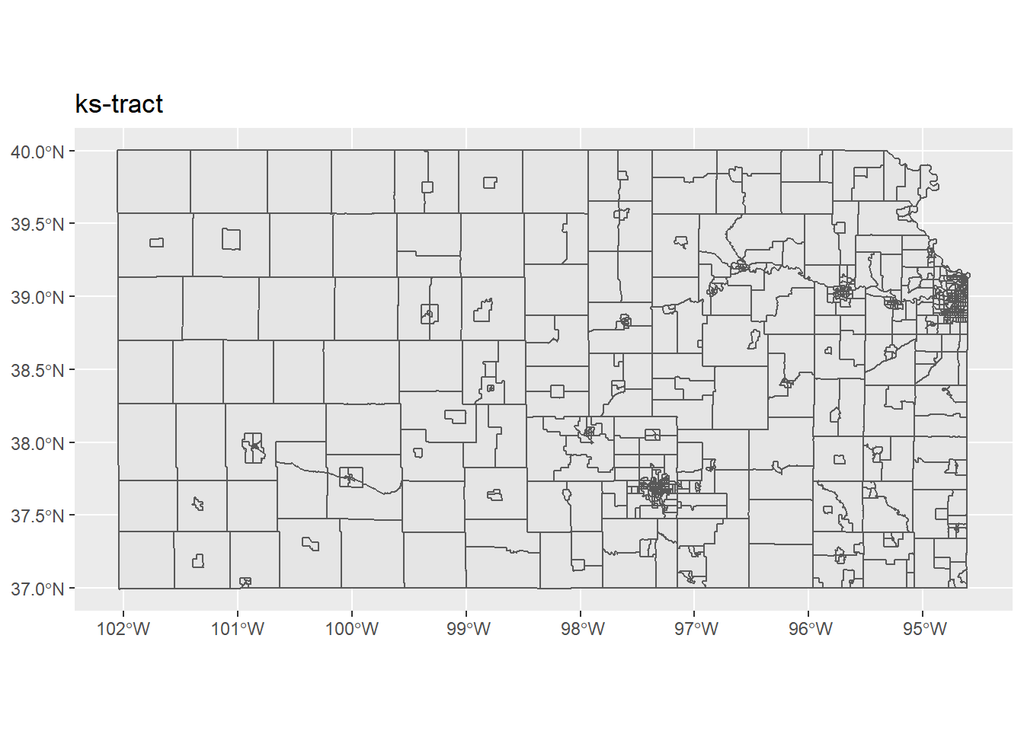

```r
all_tract_ks                           %>%
     ggplot()                              +
      geom_sf(aes())                    +
      ggtitle("ks-tract")
```

```r
path_name <- "../data"
file_name <- "tl_2021_29_tract.shp"
path_name                              %>%
  paste(file_name, sep="/")            %>%
  st_read(stringsAsFactors=FALSE)      -> all_tract_mo
head(all_tract_mo)
```

```
## Simple feature collection with 6 features and 12 fields
## Geometry type: POLYGON
## Dimension:     XY
## Bounding box:  xmin: -89.97248 ymin: 36.33681 xmax: -89.32748 ymax: 36.87091
## Geodetic CRS:  NAD83
##   STATEFP COUNTYFP TRACTCE       GEOID NAME          NAMELSAD MTFCC FUNCSTAT
## 1      29      143  960400 29143960400 9604 Census Tract 9604 G5020        S
## 2      29      143  960300 29143960300 9603 Census Tract 9603 G5020        S
## 3      29      143  960100 29143960100 9601 Census Tract 9601 G5020        S
## 4      29      143  960600 29143960600 9606 Census Tract 9606 G5020        S
## 5      29      143  960200 29143960200 9602 Census Tract 9602 G5020        S
## 6      29      143  960500 29143960500 9605 Census Tract 9605 G5020        S
##       ALAND   AWATER    INTPTLAT     INTPTLON                       geometry
## 1 377022336 21561597 +36.5088909 -089.6662818 POLYGON ((-89.86732 36.5532...
## 2  38755026  2428968 +36.5880623 -089.5616904 POLYGON ((-89.61003 36.5868...
## 3 287891722   370686 +36.7977595 -089.5923578 POLYGON ((-89.70483 36.8592...
## 4  15146537    60482 +36.4481560 -089.6873596 POLYGON ((-89.71113 36.4232...
## 5 548642900 28908393 +36.6478272 -089.5177175 POLYGON ((-89.70268 36.7390...
## 6 480482378  2906167 +36.4871669 -089.8521238 POLYGON ((-89.97248 36.3896...
```

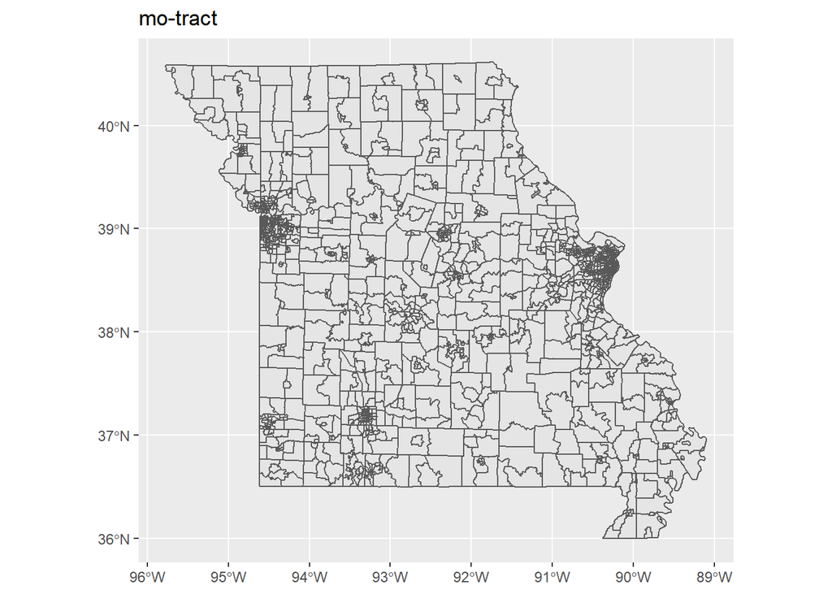

```r
all_tract_mo                           %>%
     ggplot()                              +
      geom_sf(aes())                    +
      ggtitle("mo-tract")
```

### census block groups

A census block group is a statistical division of census tracts, and generally defined to contain between 600 and 3000 people. There are files for census block groups for [Kansas](https://www2.census.gov/geo/tiger/TIGER2021/BG/tl_2021_20_bg.zip) and [Missouri](https://www2.census.gov/geo/tiger/TIGER2021/BG/tl_2021_29_bg.zip).

```r
path_name <- "../Data"
file_name <- "tl_2021_20_bg.shp"
path_name                              %>%
  paste(file_name, sep="/")            %>%
  st_read(stringsAsFactors=FALSE)      -> all_bg_ks
head(all_bg_ks)
```

```
## Simple feature collection with 6 features and 12 fields
## Geometry type: POLYGON
## Dimension:     XY
## Bounding box:  xmin: -97.35226 ymin: 37.56435 xmax: -97.22614 ymax: 37.723
## Geodetic CRS:  NAD83
##   STATEFP COUNTYFP TRACTCE BLKGRPCE        GEOID      NAMELSAD MTFCC FUNCSTAT
## 1      20      173  005501        1 201730055011 Block Group 1 G5030        S
## 2      20      173  007301        2 201730073012 Block Group 2 G5030        S
## 3      20      173  007301        3 201730073013 Block Group 3 G5030        S
## 4      20      173  007302        1 201730073021 Block Group 1 G5030        S
## 5      20      173  007500        1 201730075001 Block Group 1 G5030        S
## 6      20      173  007600        1 201730076001 Block Group 1 G5030        S
##     ALAND AWATER    INTPTLAT     INTPTLON                       geometry
## 1 2345189   5117 +37.5683788 -097.3384188 POLYGON ((-97.35226 37.5736...
## 2 1305295   5069 +37.7046912 -097.2537342 POLYGON ((-97.26227 37.7084...
## 3  623432      0 +37.6974156 -097.2493885 POLYGON ((-97.25536 37.7011...
## 4 1309677      0 +37.6902110 -097.2353240 POLYGON ((-97.24454 37.6938...
## 5  378518      0 +37.7111218 -097.2857794 POLYGON ((-97.29074 37.7087...
## 6 2183165   7778 +37.7177948 -097.2699103 POLYGON ((-97.28066 37.7218...
```

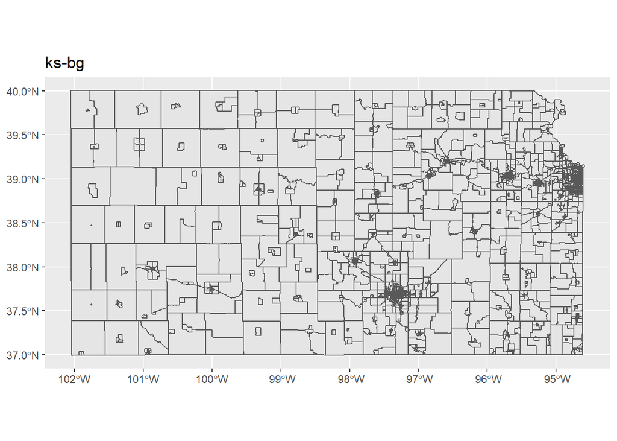

```r
all_bg_ks                              %>%
     ggplot()                           +
      geom_sf(aes())                    +
      ggtitle("ks-bg")
```

```r
path_name <- "../Data"
file_name <- "tl_2021_29_bg.shp"
path_name                              %>%
  paste(file_name, sep="/")            %>%
  st_read(stringsAsFactors=FALSE)      -> all_bg_mo
head(all_bg_mo)
```

```
## Simple feature collection with 6 features and 12 fields
## Geometry type: POLYGON
## Dimension:     XY
## Bounding box:  xmin: -91.05409 ymin: 38.90259 xmax: -90.66318 ymax: 39.12573
## Geodetic CRS:  NAD83
##   STATEFP COUNTYFP TRACTCE BLKGRPCE        GEOID      NAMELSAD MTFCC FUNCSTAT
## 1      29      113  810402        1 291138104021 Block Group 1 G5030        S
## 2      29      113  810401        2 291138104012 Block Group 2 G5030        S
## 3      29      113  810401        1 291138104011 Block Group 1 G5030        S
## 4      29      113  810306        1 291138103061 Block Group 1 G5030        S
## 5      29      113  810402        2 291138104022 Block Group 2 G5030        S
## 6      29      113  810310        2 291138103102 Block Group 2 G5030        S
##      ALAND   AWATER    INTPTLAT     INTPTLON                       geometry
## 1 62123864  3062019 +38.9471638 -090.7564015 POLYGON ((-90.82636 38.9395...
## 2 46953840  1837082 +39.0030198 -090.7324386 POLYGON ((-90.79917 39.0151...
## 3 61395180 10321136 +39.0724091 -090.7390741 POLYGON ((-90.78369 39.0351...
## 4 52625045   870286 +39.0202842 -090.9796314 POLYGON ((-91.05409 39.0514...
## 5 28895541    14649 +38.9868655 -090.7933973 POLYGON ((-90.8267 39.00014...
## 6  8116733   178881 +38.9735034 -090.9403459 POLYGON ((-90.9633 38.97724...
```

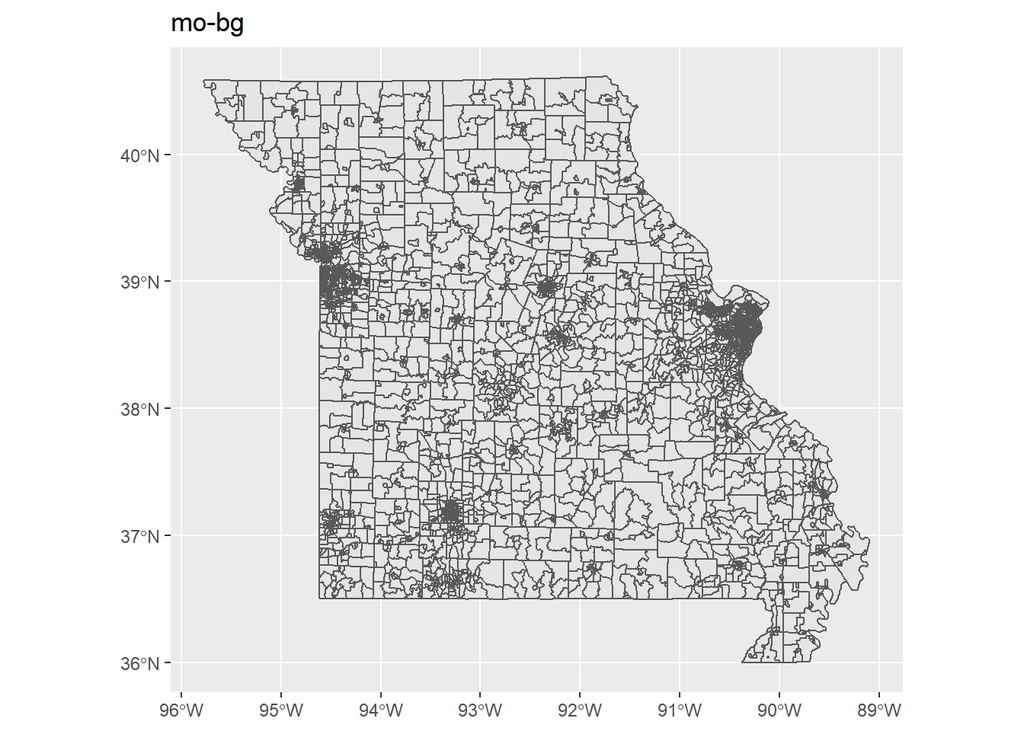

```r
all_bg_mo                              %>%
     ggplot()                           +
      geom_sf(aes())                    +
      ggtitle("mo-bg")
```

### census blocks

```r
file_name <- "tl_2020_20091_tabblock10.shp"
path_name                              %>%
  paste(file_name, sep="/")            %>%
  st_read(stringsAsFactors=FALSE)      -> johnson_county_blocks
head(johnson_county_blocks)
```

```
## Simple feature collection with 6 features and 15 fields
## Geometry type: MULTIPOLYGON
## Dimension:     XY
## Bounding box:  xmin: -94.9033 ymin: 38.75275 xmax: -94.60816 ymax: 38.97722
## Geodetic CRS:  NAD83
##   STATEFP10 COUNTYFP10 TRACTCE10 BLOCKCE10         GEOID10     NAME10 MTFCC10
## 1        20        091    052801      2007 200910528012007 Block 2007   G5040
## 2        20        091    052801      1030 200910528011030 Block 1030   G5040
## 3        20        091    053804      1050 200910538041050 Block 1050   G5040
## 4        20        091    053803      2047 200910538032047 Block 2047   G5040
## 5        20        091    052504      1005 200910525041005 Block 1005   G5040
## 6        20        091    053410      3010 200910534103010 Block 3010   G5040
##   UR10 UACE10 UATYPE10 FUNCSTAT10 ALAND10 AWATER10  INTPTLAT10   INTPTLON10
## 1    U  43912        U          S       0    18970 +38.8944152 -094.8607056
## 2    R   <NA>     <NA>          S       0    39693 +38.9366625 -094.9014718
## 3    R   <NA>     <NA>          S 2518669    63337 +38.7597302 -094.7135943
## 4    R   <NA>     <NA>          S 1327914     2296 +38.8052054 -094.6139615
## 5    U  43912        U          S  354042     1582 +38.9735988 -094.7833654
## 6    U  43912        U          S       0     5222 +38.8317213 -094.6353569
##                         geometry
## 1 MULTIPOLYGON (((-94.86153 3...
## 2 MULTIPOLYGON (((-94.90326 3...
## 3 MULTIPOLYGON (((-94.72329 3...
## 4 MULTIPOLYGON (((-94.62135 3...
## 5 MULTIPOLYGON (((-94.78777 3...
## 6 MULTIPOLYGON (((-94.63817 3...
```

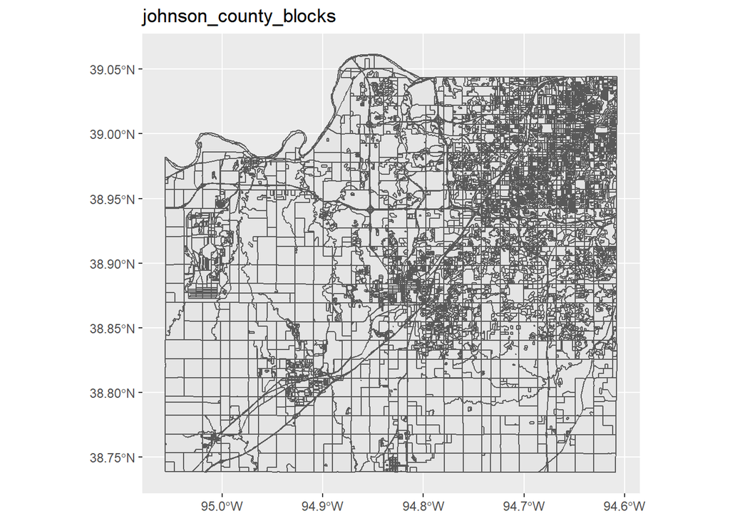

```r
johnson_county_blocks                  %>%
     ggplot()                           +
      geom_sf(aes())                    +
      ggtitle("johnson_county_blocks")
```

```r
file_name <- "tl_2020_20103_tabblock10.shp"
path_name                              %>%
  paste(file_name, sep="/")            %>%
  st_read(stringsAsFactors=FALSE)      -> leavenworth_county_blocks
head(leavenworth_county_blocks)
```

```
## Simple feature collection with 6 features and 15 fields
## Geometry type: MULTIPOLYGON
## Dimension:     XY
## Bounding box:  xmin: -95.16178 ymin: 38.98214 xmax: -94.83459 ymax: 39.27063
## Geodetic CRS:  NAD83
##   STATEFP10 COUNTYFP10 TRACTCE10 BLOCKCE10         GEOID10     NAME10 MTFCC10
## 1        20        103    071000      1052 201030710001052 Block 1052   G5040
## 2        20        103    071203      1030 201030712031030 Block 1030   G5040
## 3        20        103    071102      2000 201030711022000 Block 2000   G5040
## 4        20        103    071600      1009 201030716001009 Block 1009   G5040
## 5        20        103    071400      3069 201030714003069 Block 3069   G5040
## 6        20        103    071600      1011 201030716001011 Block 1011   G5040
##   UR10 UACE10 UATYPE10 FUNCSTAT10 ALAND10 AWATER10  INTPTLAT10   INTPTLON10
## 1    R   <NA>     <NA>          S 4377101    29415 +39.2483471 -095.0948168
## 2    R   <NA>     <NA>          S  346111    29348 +39.1696559 -094.9173097
## 3    R   <NA>     <NA>          S       0   199830 +39.2656573 -094.8434508
## 4    R   <NA>     <NA>          S 5108354    49310 +39.1366023 -095.1413897
## 5    R   <NA>     <NA>          S       0   131490 +38.9867813 -094.9722350
## 6    R   <NA>     <NA>          S       0   160655 +39.1236053 -095.1518268
##                         geometry
## 1 MULTIPOLYGON (((-95.10569 3...
## 2 MULTIPOLYGON (((-94.91946 3...
## 3 MULTIPOLYGON (((-94.85215 3...
## 4 MULTIPOLYGON (((-95.16177 3...
## 5 MULTIPOLYGON (((-94.98199 3...
## 6 MULTIPOLYGON (((-95.15492 3...
```

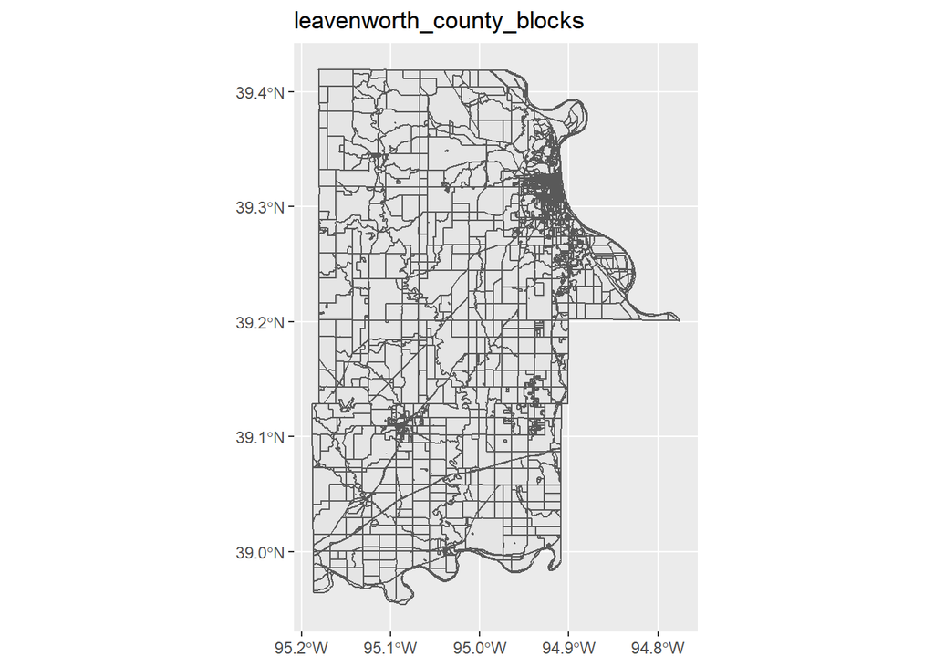

```r
leavenworth_county_blocks                         %>%
     ggplot()                              +
      geom_sf(aes())                    +
      ggtitle("leavenworth_county_blocks")
```

```r
file_name <- "tl_2020_20209_tabblock10.shp"
path_name                              %>%
  paste(file_name, sep="/")            %>%
  st_read(stringsAsFactors=FALSE)      -> wyandotte_county_blocks
head(wyandotte_county_blocks)
```

```
## Simple feature collection with 6 features and 15 fields
## Geometry type: MULTIPOLYGON
## Dimension:     XY
## Bounding box:  xmin: -94.74515 ymin: 39.07598 xmax: -94.61217 ymax: 39.1025
## Geodetic CRS:  NAD83
##   STATEFP10 COUNTYFP10 TRACTCE10 BLOCKCE10         GEOID10     NAME10 MTFCC10
## 1        20        209    044004      1022 202090440041022 Block 1022   G5040
## 2        20        209    043804      1006 202090438041006 Block 1006   G5040
## 3        20        209    040002      1055 202090400021055 Block 1055   G5040
## 4        20        209    044004      1021 202090440041021 Block 1021   G5040
## 5        20        209    043804      1111 202090438041111 Block 1111   G5040
## 6        20        209    042501      1031 202090425011031 Block 1031   G5040
##   UR10 UACE10 UATYPE10 FUNCSTAT10 ALAND10 AWATER10  INTPTLAT10   INTPTLON10
## 1    R   <NA>     <NA>          S       0    38818 +39.0776326 -094.7434580
## 2    R   <NA>     <NA>          S       0     1526 +39.0932193 -094.7096391
## 3    U  43912        U          S       0     1699 +39.0989247 -094.6128253
## 4    R   <NA>     <NA>          S       0   234153 +39.0784838 -094.7383068
## 5    U  43912        U          S       0     2404 +39.0768528 -094.6497969
## 6    U  43912        U          S       0    13043 +39.1008795 -094.6147806
##                         geometry
## 1 MULTIPOLYGON (((-94.74515 3...
## 2 MULTIPOLYGON (((-94.70994 3...
## 3 MULTIPOLYGON (((-94.61343 3...
## 4 MULTIPOLYGON (((-94.74383 3...
## 5 MULTIPOLYGON (((-94.65003 3...
## 6 MULTIPOLYGON (((-94.61584 3...
```

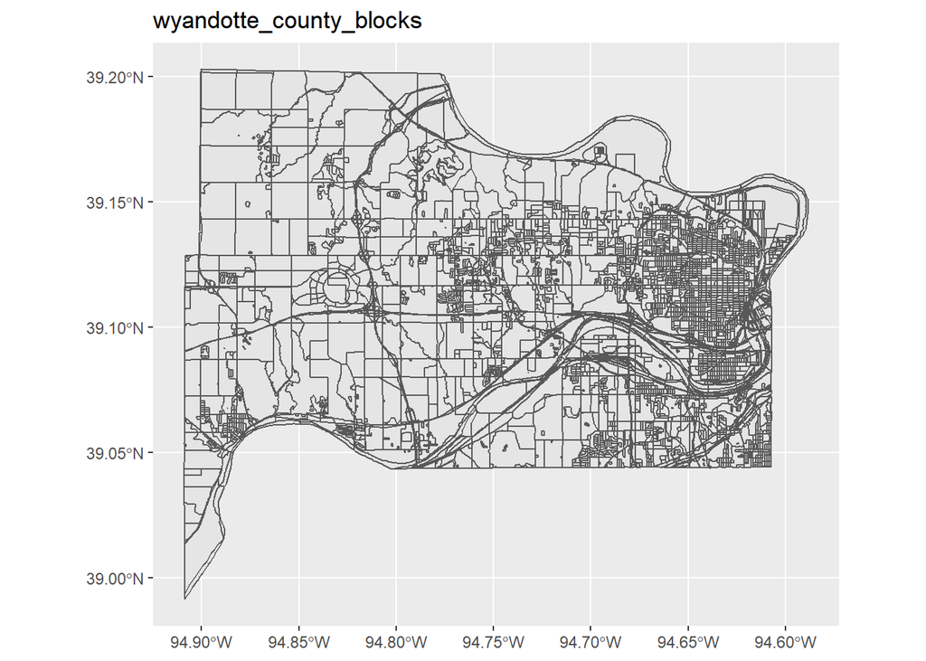

```r
wyandotte_county_blocks                %>%
  ggplot()                              +
      geom_sf(aes())                    +
      ggtitle("wyandotte_county_blocks")
```

```r
file_name <- "tl_2020_29095_tabblock10.shp"
path_name                              %>%
  paste(file_name, sep="/")            %>%
  st_read(stringsAsFactors=FALSE)      -> jackson_county_blocks
head(jackson_county_blocks)
```

```
## Simple feature collection with 6 features and 15 fields
## Geometry type: MULTIPOLYGON
## Dimension:     XY
## Bounding box:  xmin: -94.51318 ymin: 38.87511 xmax: -94.3153 ymax: 39.06195
## Geodetic CRS:  NAD83
##   STATEFP10 COUNTYFP10 TRACTCE10 BLOCKCE10         GEOID10     NAME10 MTFCC10
## 1        29        095    016300      1125 290950163001125 Block 1125   G5040
## 2        29        095    014400      1038 290950144001038 Block 1038   G5040
## 3        29        095    014502      2010 290950145022010 Block 2010   G5040
## 4        29        095    014804      1041 290950148041041 Block 1041   G5040
## 5        29        095    988300      1094 290959883001094 Block 1094   G5040
## 6        29        095    014400      2031 290950144002031 Block 2031   G5040
##   UR10 UACE10 UATYPE10 FUNCSTAT10 ALAND10 AWATER10  INTPTLAT10   INTPTLON10
## 1    U  43912        U          S  117034     5673 +39.0528357 -094.5102111
## 2    R   <NA>     <NA>          S  450173   193765 +38.9350560 -094.4605927
## 3    U  43912        U          S       0     2276 +39.0391290 -094.3493556
## 4    R   <NA>     <NA>          S 1153625      116 +39.0556505 -094.3275846
## 5    R   <NA>     <NA>          S       0    39797 +38.8789695 -094.4876980
## 6    U  48826        U          S       0    10685 +38.9429538 -094.4206606
##                         geometry
## 1 MULTIPOLYGON (((-94.51318 3...
## 2 MULTIPOLYGON (((-94.47153 3...
## 3 MULTIPOLYGON (((-94.34962 3...
## 4 MULTIPOLYGON (((-94.33685 3...
## 5 MULTIPOLYGON (((-94.48996 3...
## 6 MULTIPOLYGON (((-94.42184 3...
```

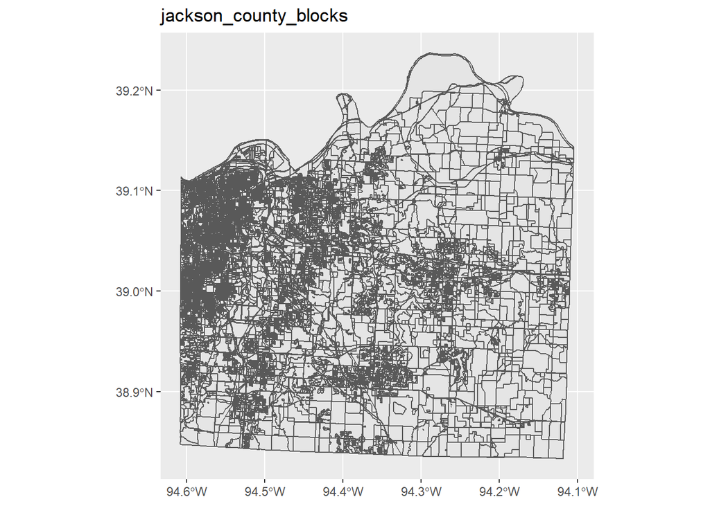

```r
jackson_county_blocks                  %>%
  ggplot()                              +
      geom_sf(aes())                    +
      ggtitle("jackson_county_blocks")
```

```r
file_name <- "tl_2020_29037_tabblock10.shp"
path_name                              %>%
  paste(file_name, sep="/")            %>%
  st_read(stringsAsFactors=FALSE)      -> cass_county_blocks
head(cass_county_blocks)
```

```
## Simple feature collection with 6 features and 15 fields
## Geometry type: POLYGON
## Dimension:     XY
## Bounding box:  xmin: -94.6091 ymin: 38.47632 xmax: -94.24056 ymax: 38.78994
## Geodetic CRS:  NAD83
##   STATEFP10 COUNTYFP10 TRACTCE10 BLOCKCE10         GEOID10     NAME10 MTFCC10
## 1        29        037    061001      1042 290370610011042 Block 1042   G5040
## 2        29        037    061001      1003 290370610011003 Block 1003   G5040
## 3        29        037    060305      1031 290370603051031 Block 1031   G5040
## 4        29        037    060700      3051 290370607003051 Block 3051   G5040
## 5        29        037    061100      2065 290370611002065 Block 2065   G5040
## 6        29        037    061200      3017 290370612003017 Block 3017   G5040
##   UR10 UACE10 UATYPE10 FUNCSTAT10 ALAND10 AWATER10  INTPTLAT10   INTPTLON10
## 1    R   <NA>     <NA>          S 3914613   127005 +38.7492476 -094.5991234
## 2    R   <NA>     <NA>          S 2395965    33908 +38.7816685 -094.5439887
## 3    R   <NA>     <NA>          S  612888    39219 +38.7862984 -094.4712714
## 4    R   <NA>     <NA>          S 1915854    31824 +38.6628656 -094.2481730
## 5    R   <NA>     <NA>          S 2570558     7985 +38.4834395 -094.5747748
## 6    R   <NA>     <NA>          S       0     1077 +38.4891357 -094.3413098
##                         geometry
## 1 POLYGON ((-94.6091 38.73864...
## 2 POLYGON ((-94.55124 38.7736...
## 3 POLYGON ((-94.47638 38.7830...
## 4 POLYGON ((-94.25914 38.6655...
## 5 POLYGON ((-94.58474 38.4767...
## 6 POLYGON ((-94.34148 38.4894...
```

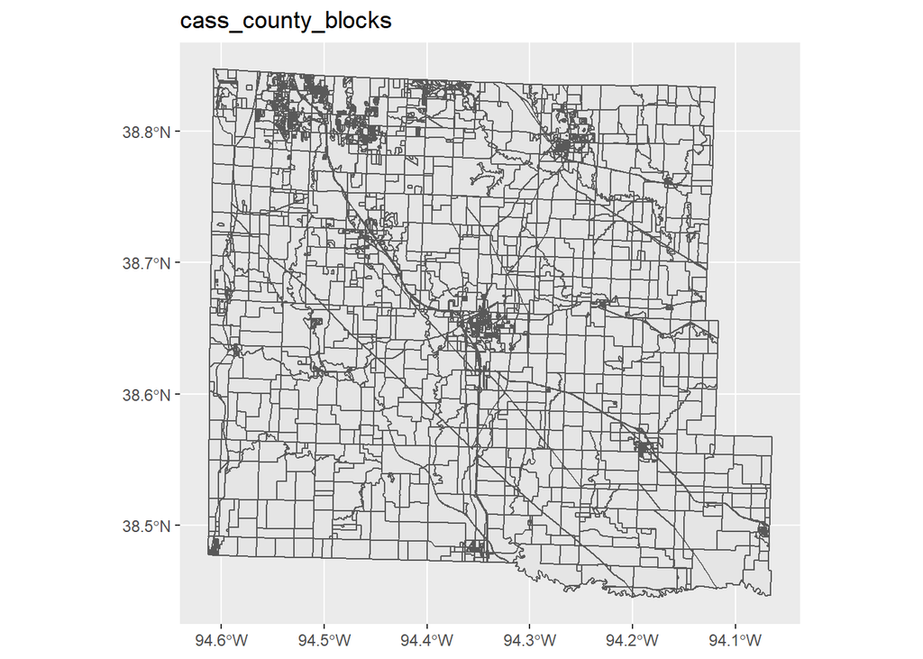

```r
cass_county_blocks                  %>%
  ggplot()                              +
      geom_sf(aes())                    +
      ggtitle("cass_county_blocks")
```

```r
file_name <- "tl_2020_29047_tabblock10.shp"
path_name                              %>%
  paste(file_name, sep="/")            %>%
  st_read(stringsAsFactors=FALSE)      -> clay_county_blocks
head(clay_county_blocks)
```

```
## Simple feature collection with 6 features and 15 fields
## Geometry type: MULTIPOLYGON
## Dimension:     XY
## Bounding box:  xmin: -94.57562 ymin: 39.24955 xmax: -94.23154 ymax: 39.4557
## Geodetic CRS:  NAD83
##   STATEFP10 COUNTYFP10 TRACTCE10 BLOCKCE10         GEOID10     NAME10 MTFCC10
## 1        29        047    021804      1044 290470218041044 Block 1044   G5040
## 2        29        047    021900      1010 290470219001010 Block 1010   G5040
## 3        29        047    021804      1034 290470218041034 Block 1034   G5040
## 4        29        047    021205      3012 290470212053012 Block 3012   G5040
## 5        29        047    021306      3011 290470213063011 Block 3011   G5040
## 6        29        047    021702      5024 290470217025024 Block 5024   G5040
##   UR10 UACE10 UATYPE10 FUNCSTAT10 ALAND10 AWATER10  INTPTLAT10   INTPTLON10
## 1    R   <NA>     <NA>          S 1723015    17630 +39.4152878 -094.3838094
## 2    R   <NA>     <NA>          S       0   674789 +39.4522978 -094.5345314
## 3    R   <NA>     <NA>          S       0    49531 +39.4212412 -094.4053333
## 4    U  43912        U          S 2556560      755 +39.2641401 -094.5453611
## 5    U  43912        U          S  298159    10481 +39.2744214 -094.5722027
## 6    U  28495        C          S       0    10703 +39.3220929 -094.2330251
##                         geometry
## 1 MULTIPOLYGON (((-94.38891 3...
## 2 MULTIPOLYGON (((-94.54208 3...
## 3 MULTIPOLYGON (((-94.40803 3...
## 4 MULTIPOLYGON (((-94.55263 3...
## 5 MULTIPOLYGON (((-94.57561 3...
## 6 MULTIPOLYGON (((-94.23401 3...
```

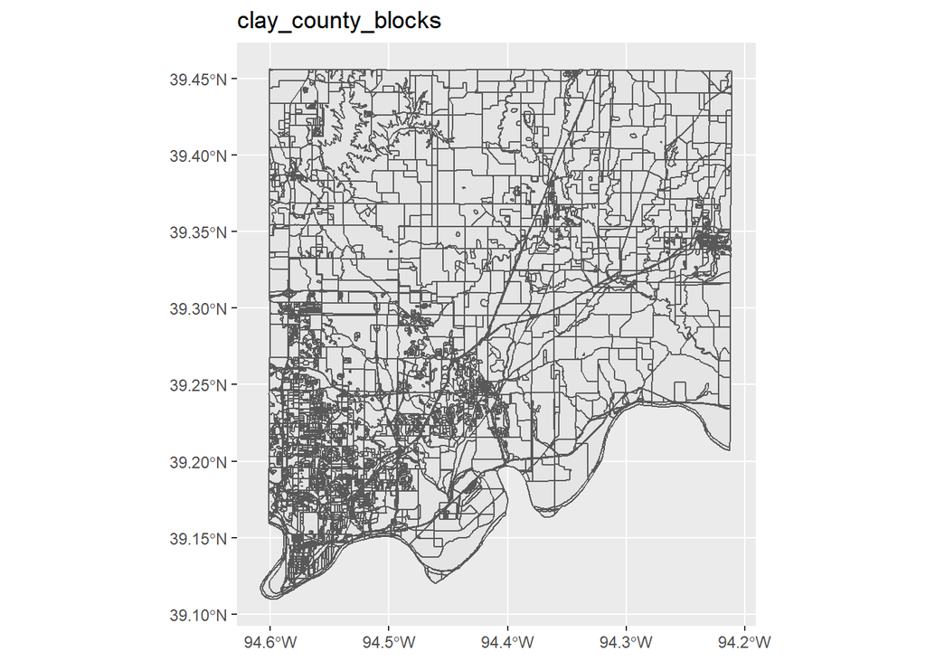

```r
clay_county_blocks                  %>%
  ggplot()                              +
      geom_sf(aes())                    +
      ggtitle("clay_county_blocks")
```

```r
file_name <- "tl_2020_20121_tabblock10.shp"
path_name                              %>%
  paste(file_name, sep="/")            %>%
  st_read(stringsAsFactors=FALSE)      -> miami_county_blocks
head(miami_county_blocks)
```

```
## Simple feature collection with 6 features and 15 fields
## Geometry type: POLYGON
## Dimension:     XY
## Bounding box:  xmin: -94.97474 ymin: 38.38925 xmax: -94.76903 ymax: 38.69307
## Geodetic CRS:  NAD83
##   STATEFP10 COUNTYFP10 TRACTCE10 BLOCKCE10         GEOID10     NAME10 MTFCC10
## 1        20        121    100100      1130 201211001001130 Block 1130   G5040
## 2        20        121    100100      3052 201211001003052 Block 3052   G5040
## 3        20        121    100500      3112 201211005003112 Block 3112   G5040
## 4        20        121    100100      2165 201211001002165 Block 2165   G5040
## 5        20        121    100601      2105 201211006012105 Block 2105   G5040
## 6        20        121    100500      1172 201211005001172 Block 1172   G5040
##   UR10 UACE10 UATYPE10 FUNCSTAT10 ALAND10 AWATER10  INTPTLAT10   INTPTLON10
## 1    R   <NA>     <NA>          S       0   250351 +38.6902732 -094.8912042
## 2    R   <NA>     <NA>          S 2562605    26697 +38.6282315 -094.9283370
## 3    R   <NA>     <NA>          S 3872196    35775 +38.5726169 -094.7790774
## 4    R   <NA>     <NA>          S  949136     5781 +38.6448983 -094.9713116
## 5    R   <NA>     <NA>          S       0     3546 +38.5609898 -094.8834228
## 6    R   <NA>     <NA>          S 4177161    26174 +38.3970308 -094.8908733
##                         geometry
## 1 POLYGON ((-94.89538 38.6893...
## 2 POLYGON ((-94.93727 38.6317...
## 3 POLYGON ((-94.78888 38.5838...
## 4 POLYGON ((-94.97473 38.6510...
## 5 POLYGON ((-94.88415 38.5617...
## 6 POLYGON ((-94.89936 38.4035...
```

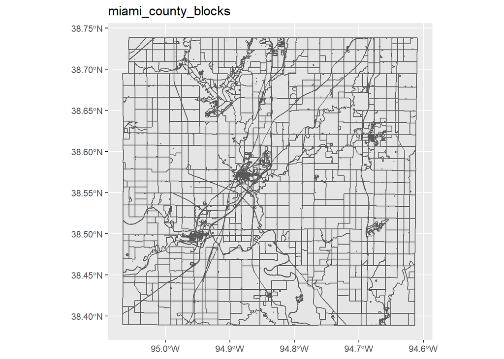

```r
miami_county_blocks                  %>%
  ggplot()                              +
      geom_sf(aes())                    +
      ggtitle("miami_county_blocks")
```

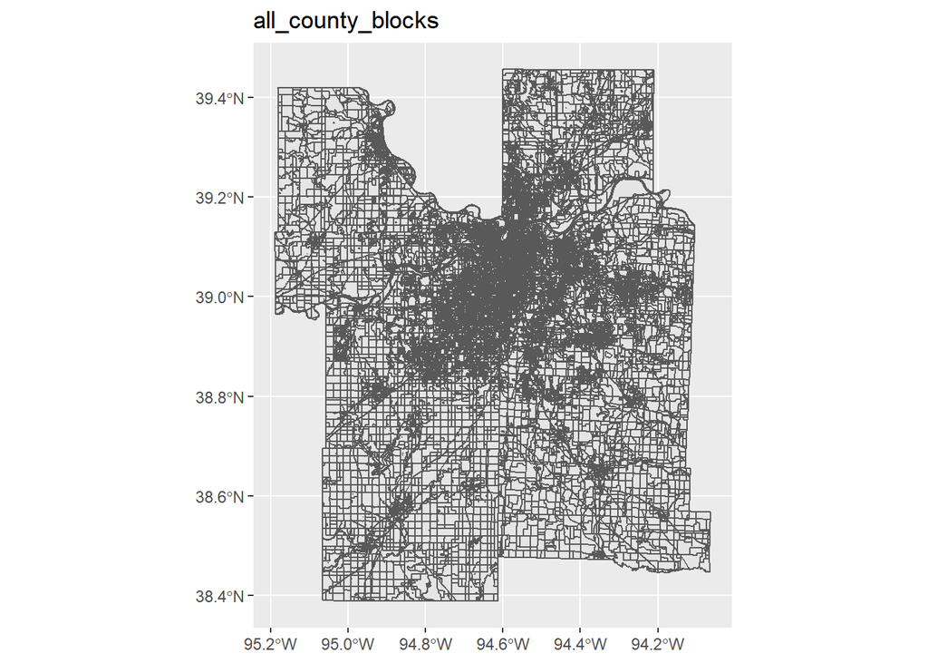

```r
johnson_county_blocks                   %>%
  bind_rows(leavenworth_county_blocks)  %>%
  bind_rows(wyandotte_county_blocks)    %>%
  bind_rows(jackson_county_blocks)      %>%
  bind_rows(cass_county_blocks)         %>%
  bind_rows(clay_county_blocks)         %>%
  bind_rows(miami_county_blocks)        %>%
   ggplot()                             +
      geom_sf(aes())                    +
      ggtitle("all_county_blocks")
```

### Community districts

This shapefile, Community_District, was provided by Neal Wilson. The various functions described in the US counties shapefiles section will be used here.

```r
file_name <- "Community_District.shp"
path_name                              %>%
  paste(file_name, sep="/")            %>%
  st_read(stringsAsFactors=FALSE)      -> Community_Districts
head(Community_Districts)
```

```
## Simple feature collection with 6 features and 8 fields
## Geometry type: POLYGON
## Dimension:     XYZ
## Bounding box:  xmin: 2758255 ymin: 1013899 xmax: 2821302 ymax: 1086876
## z_range:       zmin: 0 zmax: 0
## Projected CRS: NAD_1983_StatePlane_Missouri_West_FIPS_2403_Feet
##   State STATE_FIPS CD_ID
## 1    MO         29   106
## 2    MO         29   108
## 3    MO         29   113
## 4    MO         29   102
## 5    MO         29   129
## 6    MO         29   116
##                                                                                 shid
## 1            country:us/state:mo/place:kansas_city_city/community_district:east_side
```

[output cut: 19 more lines]

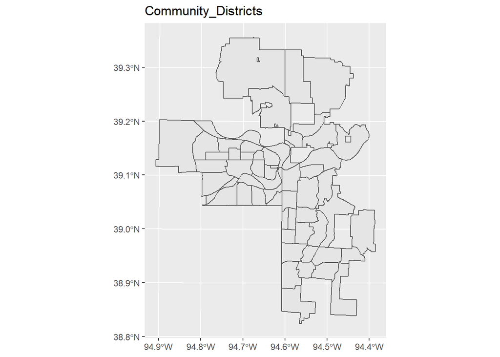

```r
Community_Districts                  %>%
  ggplot()                              +
      geom_sf(aes())                    +
      ggtitle("Community_Districts")
```

```r
Community_Districts %>%
  st_transform(crs=st_crs(all_counties)) -> cd
```

### Neighborhoods

This shapefile, Neighborhoods, was provided by Neal Wilson. The various functions described in the US counties shapefiles section will be used here.

```r
file_name <- "Neighborhoods.shp"
path_name                              %>%
  paste(file_name, sep="/")            %>%
  st_read(stringsAsFactors=FALSE)      -> Neighborhoods
head(Neighborhoods)
```

```
## Simple feature collection with 6 features and 10 fields
## Geometry type: MULTIPOLYGON
## Dimension:     XYZ
## Bounding box:  xmin: 2758295 ymin: 1025273 xmax: 2798010 ymax: 1097426
## z_range:       zmin: 0 zmax: 0
## Projected CRS: NAD_1983_StatePlane_Missouri_West_FIPS_2403_Feet
##   NID              AreaName nbr_id           CommunityD id label_long shid
## 1 244 Truman Sports Complex      1           Blue Ridge  0       <NA> <NA>
## 2 241              Area 241      2     Greater Downtown  0       <NA> <NA>
## 3 243            Swope Park      3           Swope Park  0       <NA> <NA>
## 4 245              Area 245      4 Northeast Industrial  0       <NA> <NA>
## 5 246              Area 246      5             Chouteau  0       <NA> <NA>
## 6 247      Downtown Airport      6     Downtown Airport  0       <NA> <NA>
##   Shape_Leng Shape_Le_1 Shape_Area                       geometry
## 1   22348.39   22348.39   25684112 MULTIPOLYGON Z (((2790938 1...
## 2    7813.00    7813.00    3582073 MULTIPOLYGON Z (((2770343 1...
## 3   47898.34   47898.34   68578786 MULTIPOLYGON Z (((2784236 1...
## 4   60205.57   60205.57  184656719 MULTIPOLYGON Z (((2790426 1...
## 5   28368.39   28368.39   40242276 MULTIPOLYGON Z (((2791398 1...
## 6   54946.27   54946.27   57490375 MULTIPOLYGON Z (((2763269 1...
```

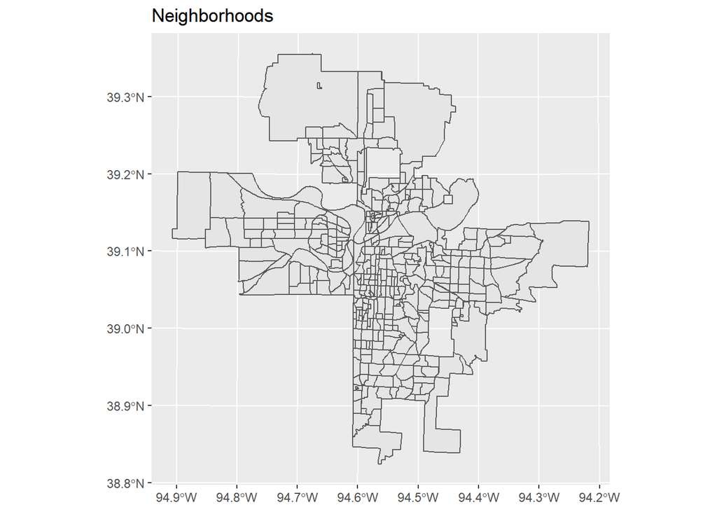

```r
Neighborhoods                          %>%
  ggplot()                              +
      geom_sf(aes())                    +
      ggtitle("Neighborhoods")
```

```r
Neighborhoods                          %>%
  st_transform(crs=st_crs(all_counties)) -> nbd
```

### Calculate intersections

#### Intersection of counties with community districts

Each community district will reside entirely inside a single county, and it is obvious to anyone familiar with the Kansas City metropolitan area which county is would be, so this is done mostly for the sake of continuity and completeness.

It is important that both the counties and the community districts use a common coordinate reference system. It is uncelar WHICH coordinate reference system is best, but this is controlled by the st_crs function of the sf package.

The st_intersects function will evaluate to TRUE if two shapefiles intersect. The st_area function will give the area of a shapefile and the st_intersection function will produce a new shapefile from the intersection of two shapefiles.

```r
all_counties                         %>%
  filter(STATEFP==20 | STATEFP==29)  ->       ks_mo_counties
ks_mo_counties                       %>%
  filter(STATEFP==29 & COUNTYFP=="095")               %>%
  st_intersects( cd, sparse=FALSE) -> intersect_matrix
```

```
## st_as_s2(): dropping Z and/or M coordinate
```

```r
 print(intersect_matrix)
```

```
##      [,1] [,2] [,3] [,4] [,5] [,6] [,7] [,8] [,9] [,10] [,11] [,12] [,13] [,14]
## [1,] TRUE TRUE TRUE TRUE TRUE TRUE TRUE TRUE TRUE  TRUE  TRUE  TRUE  TRUE  TRUE
##      [,15] [,16] [,17] [,18] [,19] [,20] [,21] [,22] [,23] [,24] [,25] [,26]
## [1,]  TRUE  TRUE  TRUE FALSE FALSE  TRUE FALSE  TRUE FALSE  TRUE  TRUE  TRUE
##      [,27] [,28] [,29] [,30] [,31] [,32] [,33] [,34] [,35] [,36] [,37] [,38]
## [1,]  TRUE  TRUE  TRUE  TRUE FALSE FALSE FALSE FALSE FALSE FALSE FALSE FALSE
##      [,39] [,40] [,41] [,42] [,43] [,44] [,45] [,46] [,47] [,48] [,49] [,50]
## [1,] FALSE FALSE FALSE FALSE FALSE FALSE FALSE FALSE FALSE FALSE FALSE FALSE
##      [,51] [,52] [,53] [,54] [,55] [,56] [,57] [,58] [,59]
## [1,] FALSE  TRUE  TRUE  TRUE FALSE FALSE FALSE FALSE FALSE
```

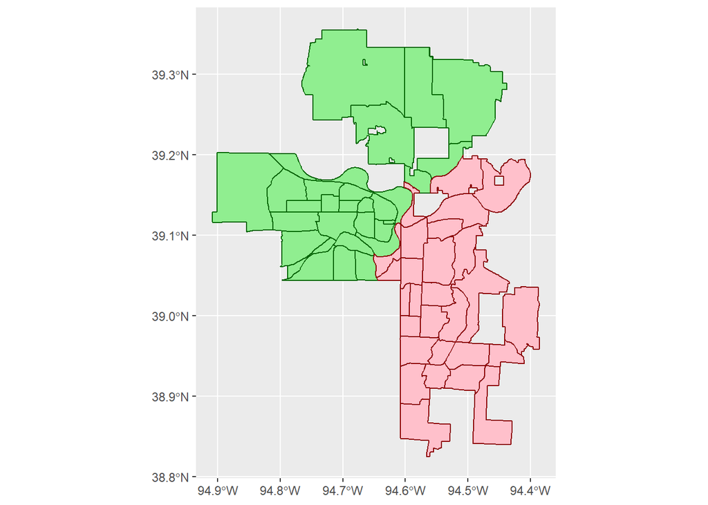

```r
 ggplot(data=cd, aes()) +
        geom_sf(fill="lightgreen", col="darkgreen") +
        geom_sf(data=cd[intersect_matrix, ], fill="pink", col="darkred")
```

#### Intersection of counties with neighborhoods

Again, each neighborhood will reside in a single county. The various functions described in the intersection of counties with community districts section will be used here.

```r
all_counties                         %>%
  filter(STATEFP==20 | STATEFP==29)  ->       ks_mo_counties
ks_mo_counties                       %>%
  filter(STATEFP==29 & COUNTYFP=="095")               %>%
  st_intersects( nbd, sparse=FALSE) -> intersect_matrix
```

```
## st_as_s2(): dropping Z and/or M coordinate
```

```r
 print(intersect_matrix)
```

```
##      [,1] [,2] [,3] [,4]  [,5] [,6]  [,7] [,8]  [,9] [,10] [,11] [,12] [,13]
## [1,] TRUE TRUE TRUE TRUE FALSE TRUE FALSE TRUE FALSE FALSE FALSE FALSE FALSE
##      [,14] [,15] [,16] [,17] [,18] [,19] [,20] [,21] [,22] [,23] [,24] [,25]
## [1,] FALSE FALSE FALSE FALSE FALSE FALSE FALSE FALSE FALSE FALSE FALSE FALSE
##      [,26] [,27] [,28] [,29] [,30] [,31] [,32] [,33] [,34] [,35] [,36] [,37]
## [1,] FALSE FALSE FALSE FALSE FALSE FALSE FALSE FALSE FALSE FALSE FALSE  TRUE
##      [,38] [,39] [,40] [,41] [,42] [,43] [,44] [,45] [,46] [,47] [,48] [,49]
## [1,] FALSE FALSE FALSE FALSE FALSE FALSE FALSE FALSE FALSE FALSE FALSE FALSE
##      [,50] [,51] [,52] [,53] [,54] [,55] [,56] [,57] [,58] [,59] [,60] [,61]
## [1,] FALSE FALSE FALSE FALSE FALSE FALSE FALSE FALSE FALSE FALSE FALSE FALSE
##      [,62] [,63] [,64] [,65] [,66] [,67] [,68] [,69] [,70] [,71] [,72] [,73]
## [1,] FALSE FALSE FALSE FALSE FALSE FALSE FALSE FALSE FALSE FALSE  TRUE  TRUE
##      [,74] [,75] [,76] [,77] [,78] [,79] [,80] [,81] [,82] [,83] [,84] [,85]
## [1,]  TRUE  TRUE  TRUE  TRUE  TRUE  TRUE  TRUE  TRUE  TRUE  TRUE  TRUE FALSE
##      [,86] [,87] [,88] [,89] [,90] [,91] [,92] [,93] [,94] [,95] [,96] [,97]
## [1,]  TRUE  TRUE  TRUE  TRUE FALSE  TRUE  TRUE  TRUE  TRUE FALSE  TRUE  TRUE
##      [,98] [,99] [,100] [,101] [,102] [,103] [,104] [,105] [,106] [,107] [,108]
## [1,]  TRUE  TRUE   TRUE   TRUE  FALSE  FALSE   TRUE  FALSE  FALSE  FALSE  FALSE
##      [,109] [,110] [,111] [,112] [,113] [,114] [,115] [,116] [,117] [,118]
## [1,]  FALSE   TRUE  FALSE  FALSE  FALSE  FALSE  FALSE   TRUE   TRUE   TRUE
##      [,119] [,120] [,121] [,122] [,123] [,124] [,125] [,126] [,127] [,128]
## [1,]  FALSE  FALSE   TRUE  FALSE   TRUE   TRUE   TRUE  FALSE   TRUE  FALSE
##      [,129] [,130] [,131] [,132] [,133] [,134] [,135] [,136] [,137] [,138]
## [1,]   TRUE   TRUE   TRUE   TRUE  FALSE   TRUE  FALSE   TRUE   TRUE   TRUE
##      [,139] [,140] [,141] [,142] [,143] [,144] [,145] [,146] [,147] [,148]
## [1,]   TRUE  FALSE   TRUE   TRUE   TRUE   TRUE   TRUE   TRUE   TRUE   TRUE
##      [,149] [,150] [,151] [,152] [,153] [,154] [,155] [,156] [,157] [,158]
## [1,]   TRUE   TRUE   TRUE  FALSE   TRUE   TRUE   TRUE   TRUE   TRUE   TRUE
##      [,159] [,160] [,161] [,162] [,163] [,164] [,165] [,166] [,167] [,168]
## [1,]  FALSE   TRUE   TRUE   TRUE  FALSE  FALSE   TRUE   TRUE   TRUE   TRUE
##      [,169] [,170] [,171] [,172] [,173] [,174] [,175] [,176] [,177] [,178]
## [1,]   TRUE   TRUE   TRUE   TRUE  FALSE   TRUE  FALSE  FALSE   TRUE  FALSE
##      [,179] [,180] [,181] [,182] [,183] [,184] [,185] [,186] [,187] [,188]
## [1,]   TRUE  FALSE   TRUE  FALSE   TRUE   TRUE   TRUE   TRUE   TRUE  FALSE
##      [,189] [,190] [,191] [,192] [,193] [,194] [,195] [,196] [,197] [,198]
## [1,]  FALSE  FALSE   TRUE  FALSE   TRUE   TRUE  FALSE   TRUE  FALSE  FALSE
##      [,199] [,200] [,201] [,202] [,203] [,204] [,205] [,206] [,207] [,208]
## [1,]   TRUE   TRUE   TRUE  FALSE   TRUE   TRUE   TRUE   TRUE  FALSE   TRUE
##      [,209] [,210] [,211] [,212] [,213] [,214] [,215] [,216] [,217] [,218]
## [1,]   TRUE   TRUE  FALSE  FALSE   TRUE   TRUE   TRUE   TRUE   TRUE   TRUE
```

[output cut: 17 more lines]

```
## [1,]   TRUE   TRUE   TRUE   TRUE   TRUE   TRUE   TRUE   TRUE  FALSE   TRUE
##      [,309] [,310] [,311] [,312] [,313] [,314] [,315] [,316] [,317] [,318]
## [1,]  FALSE   TRUE   TRUE   TRUE   TRUE   TRUE   TRUE   TRUE   TRUE   TRUE
##      [,319] [,320] [,321] [,322] [,323] [,324] [,325] [,326] [,327] [,328]
## [1,]   TRUE   TRUE   TRUE   TRUE   TRUE   TRUE   TRUE   TRUE   TRUE   TRUE
##      [,329] [,330] [,331] [,332] [,333] [,334] [,335] [,336] [,337] [,338]
## [1,]   TRUE   TRUE   TRUE   TRUE   TRUE   TRUE   TRUE   TRUE  FALSE   TRUE
##      [,339] [,340] [,341] [,342] [,343] [,344] [,345] [,346] [,347] [,348]
## [1,]   TRUE   TRUE   TRUE   TRUE   TRUE   TRUE   TRUE   TRUE   TRUE   TRUE
##      [,349] [,350] [,351] [,352] [,353] [,354] [,355] [,356] [,357] [,358]
## [1,]   TRUE   TRUE   TRUE   TRUE   TRUE   TRUE   TRUE   TRUE   TRUE   TRUE
##      [,359] [,360] [,361] [,362] [,363] [,364] [,365] [,366] [,367] [,368]
## [1,]   TRUE   TRUE   TRUE   TRUE   TRUE   TRUE   TRUE   TRUE   TRUE   TRUE
##      [,369] [,370] [,371] [,372] [,373] [,374] [,375]
## [1,]   TRUE   TRUE   TRUE   TRUE   TRUE   TRUE   TRUE
```

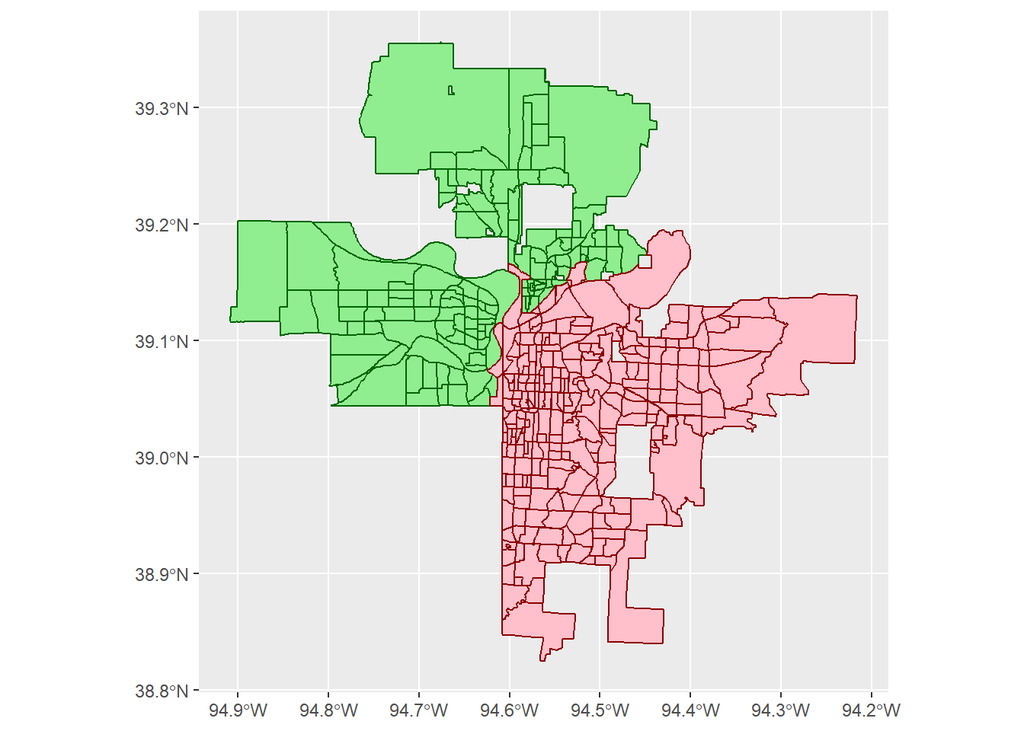

```r
 ggplot(data=nbd, aes()) +
        geom_sf(fill="lightgreen", col="darkgreen") +
        geom_sf(data=nbd[intersect_matrix, ], fill="pink", col="darkred")
```

### Census redistricting files

The Census redistricting files are found in a [different location](https://www.census.gov/programs-surveys/decennial-census/about/rdo/summary-files.html) on the Census website. You may wish to review the [Census help videos](https://www.census.gov/data/academy/courses/2020-census-redistricting-data.html) on redistricting. There are separate redistricting files for [Kansas](https://www2.census.gov/programs-surveys/decennial/2020/data/01-Redistricting_File--PL_94-171/Kansas/ks2020.pl.zip) and [Missouri](https://www2.census.gov/programs-surveys/decennial/2020/data/01-Redistricting_File--PL_94-171/Missouri/mo2020.pl.zip). The Census Bureau provides [R code](https://www2.census.gov/programs-surveys/decennial/rdo/about/2020-census-program/Phase3/SupportMaterials/2020PL_R_import_scripts.zip) for reading these files.

### American Community survey

This work will take advantage of the acs library.